# Prediction on the Weight Lifting Exercise

Jessie J. Q

January 30, 2019

## Background

Using devices such as Jawbone Up, Nike FuelBand, and Fitbit it is now possible to collect a large amount of data about personal activity relatively inexpensively. These type of devices are part of the quantified self movement - a group of enthusiasts who take measurements about themselves regularly to improve their health, to find patterns in their behavior, or because they are tech geeks. One thing that people regularly do is quantify how much of a particular activity they do, but they rarely quantify how well they do it. In this project, your goal will be to use data from accelerometers on the belt, forearm, arm, and dumbell of 6 participants. They were asked to perform barbell lifts correctly and incorrectly in 5 different ways.

## Data

The training data for this project are available here: https://d396qusza40orc.cloudfront.net/predmachlearn/pml-training.csv The test data are available here: https://d396qusza40orc.cloudfront.net/predmachlearn/pml-testing.csv The data for this project come from this source: http://groupware.les.inf.puc-rio.br/har. If you use the document you create for this class for any purpose please cite them as they have been very generous in allowing their data to be used for this kind of assignment.

```r
dim(pml_training)
```

```
## [1] 19622   160
```

```r
dim(pml_testing)
```

```
## [1]  20 160
```

## Data Preparation

1. Remove variables that most values are NA.  
   In this dataset, some columns have more than 90% of their value as NA.They won’t provide any value but slow down the processing and increase computational effort.
2. Remove near zero values (NZV).  
   In this dataset, many values are zero or near zero. These data are removed to facilitate faster and more efficient analysis.

```r
remove_nzv <- nearZeroVar(training_na, names = TRUE, freqCut = 2, uniqueCut = 20)
remove_nzv
```

```
## [1] "new_window"    "roll_arm"      "pitch_arm"     "yaw_arm"
## [5] "roll_forearm"  "pitch_forearm" "yaw_forearm"
```

```r
training_nzv <- training_na[ , !(names(training_na) %in% remove_nzv)]

knitr::opts_chunk$set(echo = TRUE)
```

3. Remove irrelevant variables.  
   The first 6 columns are not relevant to further analysis, not related to any dependent variables.

```r
training_irr <- training_nzv[ , -c(1:6)]
```

4. Remove highly correlated variables.  
   First, find factor variables and remove them since findCorrelation function in R only work for numeric variables.  
   And then, find highly correlation variables (cutoff=0.9) and remove them.

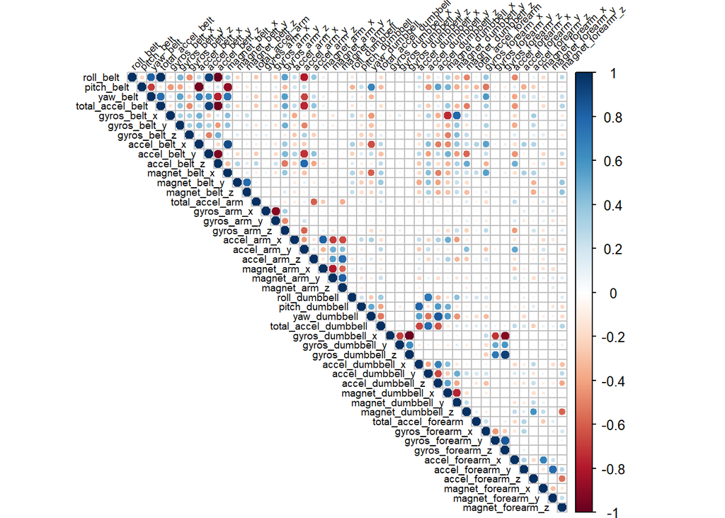

```r
corr_data <- cor(training_irr[ , -47])

corrplot(corr_data, method = "circle", type = "upper",
         tl.cex = 0.6, tl.col = "black", tl.srt = 45)
```

```r
high_corr <- findCorrelation(corr_data, cutoff = 0.9, verbose = TRUE)
```

```
## Compare row 10  and column  1 with corr  0.992
##   Means:  0.279 vs 0.176 so flagging column 10
## Compare row 1  and column  9 with corr  0.925
##   Means:  0.256 vs 0.172 so flagging column 1
## Compare row 9  and column  4 with corr  0.928
##   Means:  0.239 vs 0.168 so flagging column 9
## Compare row 8  and column  2 with corr  0.966
##   Means:  0.257 vs 0.164 so flagging column 8
## Compare row 16  and column  15 with corr  0.918
##   Means:  0.099 vs 0.164 so flagging column 15
## Compare row 40  and column  28 with corr  0.914
##   Means:  0.114 vs 0.168 so flagging column 28
## Compare row 40  and column  30 with corr  0.933
##   Means:  0.093 vs 0.172 so flagging column 30
## All correlations <= 0.9
```

```r
training <-  training_irr[,-high_corr]
dim(training)
```

```
## [1] 19622    40
```

## Modeling

Split training set into train and test (75% for training, 25% for validation) for cross validation

```r
inTrain <- createDataPartition(y = training$classe, p = 0.75, list = FALSE)
train <- training[inTrain, ]
test <- training[-inTrain, ]

dim(train)
```

```
## [1] 14718    40
```

```r
dim(test)
```

```
## [1] 4904   40
```

## Decision Tree Modeling

Fit the tree to training dataset, summarized the finalModel and plot the tree. (rpart in caret package is too slow, use prp instead)

```r
set.seed(1471)
modFit <- train(classe ~ ., method = "rpart", data = train)
print(modFit$finalModel)
```

```
## n= 14718
##
## node), split, n, loss, yval, (yprob)
##       * denotes terminal node
##
## 1) root 14718 10533 A (0.28 0.19 0.17 0.16 0.18)
##   2) magnet_belt_y>=555.5 13601  9417 A (0.31 0.21 0.19 0.16 0.13)
##     4) magnet_arm_x< 70.5 5772  2957 A (0.49 0.18 0.21 0.059 0.063) *
##     5) magnet_arm_x>=70.5 7829  5961 D (0.17 0.23 0.18 0.24 0.18) *
##   3) magnet_belt_y< 555.5 1117   208 E (0.0009 0.0027 0.0009 0.18 0.81) *
```

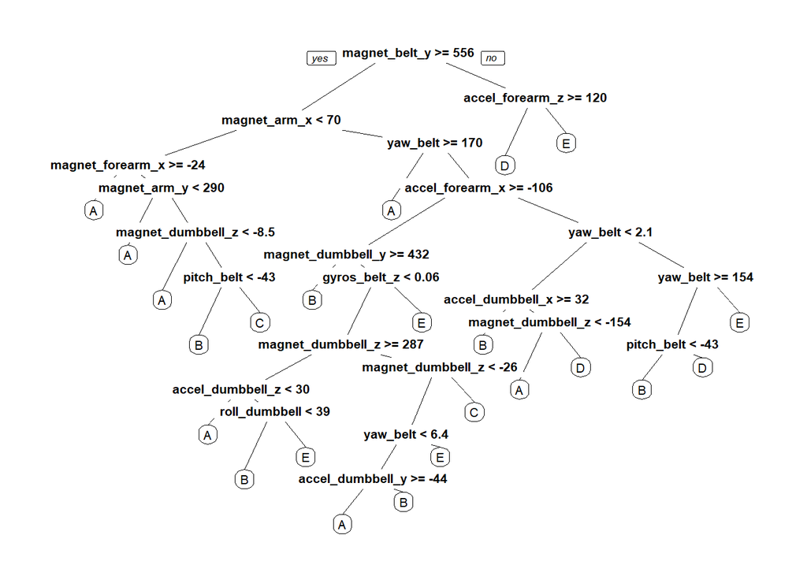

```r
train_tree <- rpart(classe ~ ., data = train, method="class")
prp(train_tree)
```

```r
predict_tree <- predict(train_tree, newdata = test, type="class")
conf_matrix <- confusionMatrix(predict_tree, test$classe)
conf_matrix
```

```
## Confusion Matrix and Statistics
##
##           Reference
## Prediction    A    B    C    D    E
##          A 1166  293  226  113   75
##          B   60  394   41   29   82
##          C   59  169  431  121  119
##          D  106   87  120  470   68
##          E    4    6   37   71  557
##
## Overall Statistics
##
##                Accuracy : 0.6154
##                  95% CI : (0.6016, 0.6291)
##     No Information Rate : 0.2845
##     P-Value [Acc > NIR] : < 2.2e-16
##
##                   Kappa : 0.508
##  Mcnemar's Test P-Value : < 2.2e-16
##
## Statistics by Class:
##
##                      Class: A Class: B Class: C Class: D Class: E
## Sensitivity            0.8358  0.41517  0.50409  0.58458   0.6182
## Specificity            0.7985  0.94640  0.88442  0.90707   0.9705
## Pos Pred Value         0.6225  0.65017  0.47942  0.55229   0.8252
## Neg Pred Value         0.9244  0.87087  0.89413  0.91759   0.9187
## Prevalence             0.2845  0.19352  0.17435  0.16395   0.1837
## Detection Rate         0.2378  0.08034  0.08789  0.09584   0.1136
## Detection Prevalence   0.3819  0.12357  0.18332  0.17353   0.1376
## Balanced Accuracy      0.8172  0.68079  0.69425  0.74583   0.7944
```

## Random Forest Modeling

```r
set.seed(1471)
train_ctrl_rf <- trainControl(method = "repeatedcv", number = 5, repeats = 2)
train_rf  <- train(classe ~ ., data = train, method = "rf", trControl = train_ctrl_rf, verbose = FALSE)
print(train_rf$finalModel)
```

```
##
## Call:
##  randomForest(x = x, y = y, mtry = param$mtry, verbose = FALSE)
##                Type of random forest: classification
##                      Number of trees: 500
## No. of variables tried at each split: 20
##
##         OOB estimate of  error rate: 0.76%
## Confusion matrix:
##      A    B    C    D    E class.error
## A 4173    5    2    4    1 0.002867384
## B   25 2807   13    0    3 0.014396067
## C    2   14 2549    2    0 0.007012076
## D    1    0   28 2381    2 0.012852405
## E    0    2    3    5 2696 0.003695492
```

```r
predict_rf <- predict(train_rf, newdata = test)
conf_matrix_rf <- confusionMatrix(predict_rf, test$classe)
conf_matrix_rf
```

```
## Confusion Matrix and Statistics
##
##           Reference
## Prediction    A    B    C    D    E
##          A 1389   11    0    0    1
##          B    2  931    5    0    0
##          C    0    6  850    5    1
##          D    2    1    0  799    2
##          E    2    0    0    0  897
##
## Overall Statistics
##
##                Accuracy : 0.9923
##                  95% CI : (0.9894, 0.9945)
##     No Information Rate : 0.2845
##     P-Value [Acc > NIR] : < 2.2e-16
##
##                   Kappa : 0.9902
##  Mcnemar's Test P-Value : NA
##
## Statistics by Class:
##
##                      Class: A Class: B Class: C Class: D Class: E
## Sensitivity            0.9957   0.9810   0.9942   0.9938   0.9956
## Specificity            0.9966   0.9982   0.9970   0.9988   0.9995
## Pos Pred Value         0.9914   0.9925   0.9861   0.9938   0.9978
## Neg Pred Value         0.9983   0.9955   0.9988   0.9988   0.9990
## Prevalence             0.2845   0.1935   0.1743   0.1639   0.1837
## Detection Rate         0.2832   0.1898   0.1733   0.1629   0.1829
## Detection Prevalence   0.2857   0.1913   0.1758   0.1639   0.1833
## Balanced Accuracy      0.9961   0.9896   0.9956   0.9963   0.9975
```

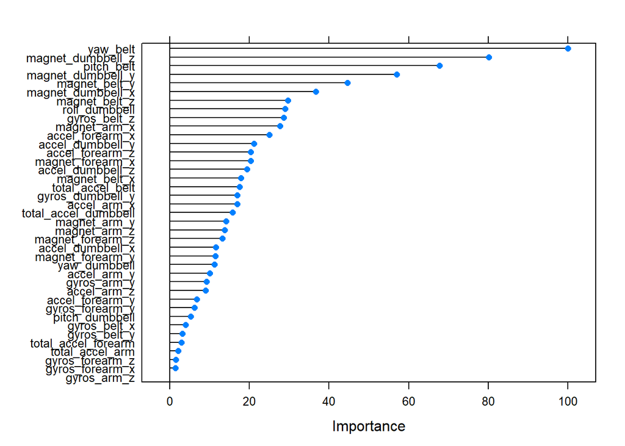

```r
plot(varImp(train_rf))
```

## Conclusion

As conclusion, Randome Forest model is selected to predict 20 differet test cases

## Deployment

Use Random Forest model to predict 20 different test cases

```r
predict_20 <- predict(train_rf, newdata = pml_testing)
predict_20
```

```
##  [1] B A B A A E D B A A B C B A E E A B B B
## Levels: A B C D E
```